# Factor analysis

### 3.3. Data visualization

Here, the goal is to show how I visualized the relationship between each question item and three factors. I did this in two steps. I first extracted factor loadings (correlation coefficients between observed data and factors) and then put them into a dataframe.

Next, I visualized the relationship between factor loadings and the three factors.

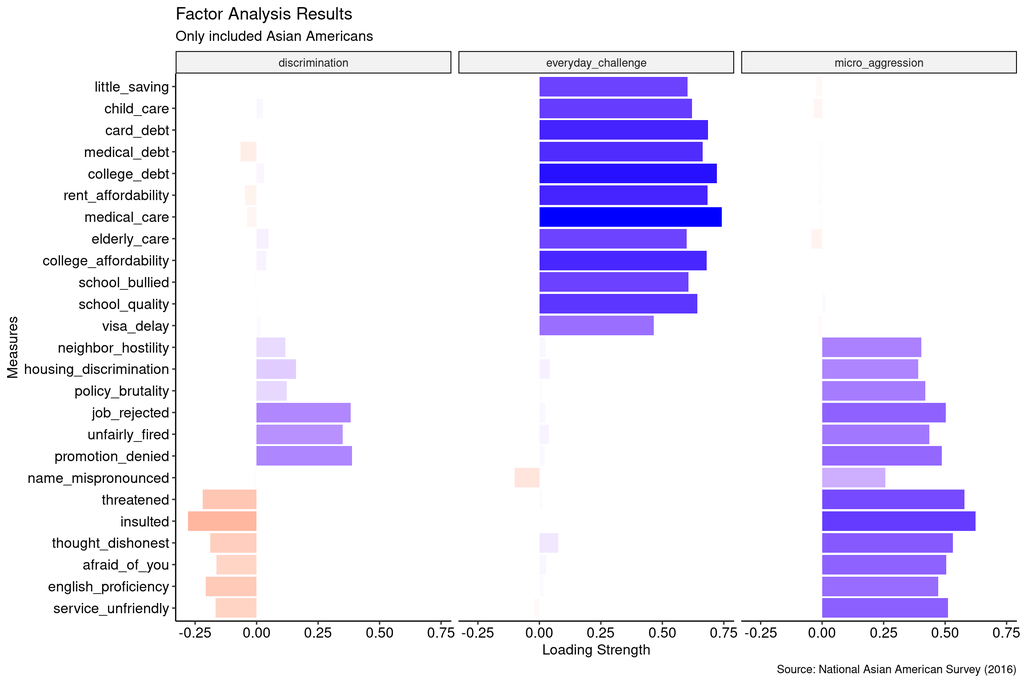

## 5. Replacing the survey items with the index variables.

I then replaced the survey items related to lived racial experience with the three index variables (weighted average responses).

## 6. Data visualization

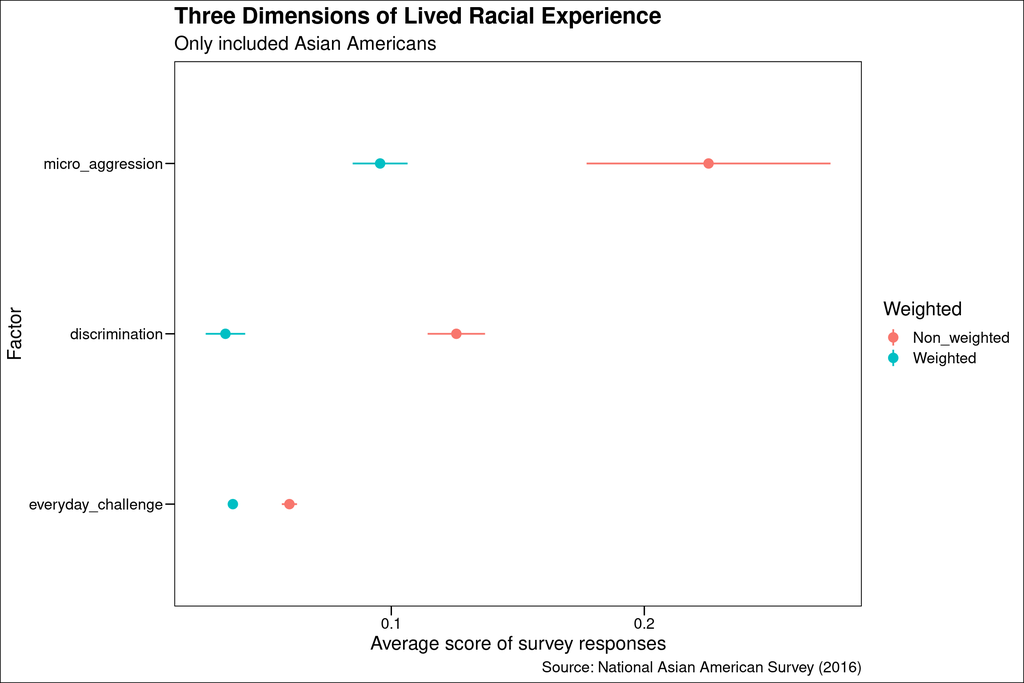